# Working with groups

Ben Whalley, Paul Sharpe, Sonja Heintz

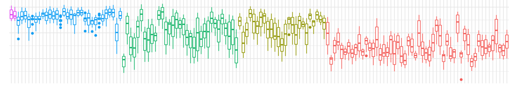

# Overview

As researchers, we often collect data from two or more groups.

Group allocations are *categorical* variables. They are stored in a special way by R, which makes it easier to display them on graphs and use them in analyses.

In this workshop we learn to how to use categorical variables in boxplots, to add colour to scatterplots, and to make tables of descriptive statistics which you will need in your coursework and project reports.

### Techniques covered

- Making boxplots
- Adding colour to a plot
- Using different types of data and visual scales
- Using `group_by()` to make a summary table and compare groups

# Making boxplots

[video not shown]

**Video summary**

- Boxplots are useful for comparing categorised data
- Use `aes()` with `ggplot()` to choose a categorical column as the x axis
- `geom_boxplot()` draws boxes and whiskers for each category
- The box describes the [*interquartile range*](https://www.bbc.co.uk/bitesize/guides/zx7rk7h/revision/2)
- The midpoint is the *median*
- Individual points show *outliers* in the data

**Code examples**

```r
iris %>%
  ggplot(aes(x=Species, y=Petal.Length)) +  # specify dataset columns
  geom_boxplot()                            # add the boxes
```

**Video Transcript**

Boxplots are useful for visualising differences between categories or groups.

Using `ggplot()`, making a boxplot is similar to a scatterplot.

If we haven’t already done it, we’d need to load the `tidyverse`:

```r
library(tidyverse)
```

To make the plot, we first choose the data we want to plot and add a pipe to the end of the line to send this data to the next command:

- From the code below select only first line
- Also show selecting/executing just the name of the dataset and how this displays the data
- Emphaise the importance of breaking code down and running sub-steps separately

Next we use `ggplot()` and `aes(x = ..., y = ...)` to select the columns we want to use in the data. `aes` is short for *aesthetics* which means ‘something you can see’. So the `aes()` function defines what will be able to see on the plot — the axes, and other features like color.

This time we have chosen `Species` for the x axis, because it is a *categorical* variable.

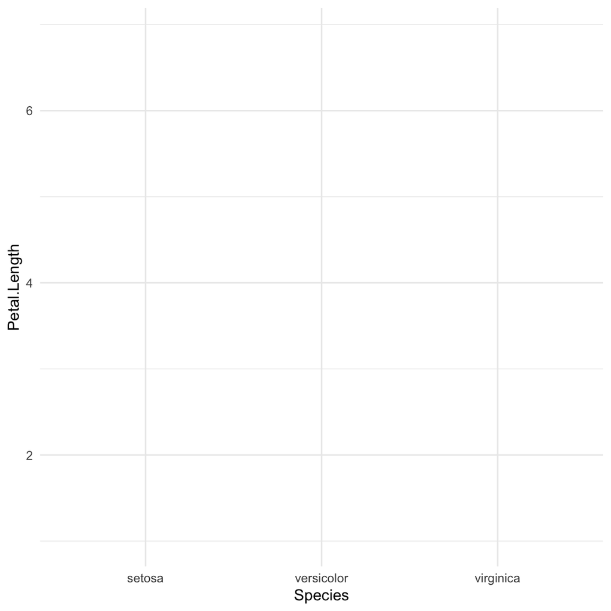

```r
iris %>%
  ggplot(aes(x = Species, y = Petal.Length))
```

- Demonstrate running code above
- Also show using autocomplete in RStudio when writing the code above

You’ll notice that I used the RStudio autocomplete feature to write function and column names from our dataset. This makes things much easier — especially for column names. If you type column names by hand it’s easy to make spelling errors or typos, and this leads to errors in R.

If we run the code so far, `ggplot()` draws the plot axes, but doesn’t add the data yet:

Run the code so far

So far we have said *what* we want to show on our plot, but not *how* it should be shown.

To finish, we add `geom_boxplot()` which actually draws the boxes:

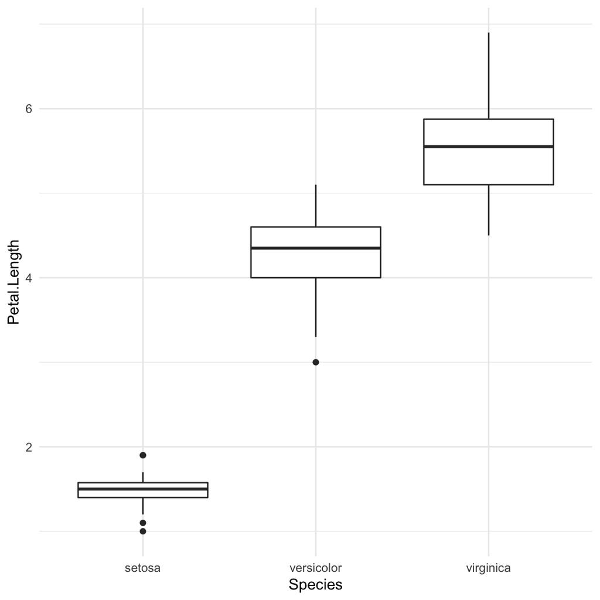

```r
iris %>%
  ggplot(aes(x = Species, y = Petal.Length)) +
  geom_boxplot()
```

Note that I used a `+` symbol to add the boxplot layer to our graph.

So, now we have a boxplot, with one box drawn for each value of `Species`.

### Interpreting boxplots

In a boxplot:

- The thick line across the middle of the box is the *median* or midpoint of the data
- The height of the box indicates the [*interquartile range*](https://www.bbc.co.uk/bitesize/guides/zx7rk7h/revision/2) (IQR). This means the box contains 50% of the datapoints. A wider IQR indicates greater variation (spread) in a dataset.
- The meaning of the “whiskers” (the lines above the top, and below the bottom of the box) varies a little bit depending on the software you use — but they always show the range/spread of the data. The default in `ggplot()` are whiskers with lengths covering data points no more, or less than 1.5 times the IQR.
- Any data point outside the range of the whiskers is described as an ‘outlying point’ or ‘outlier’. Each outlier is plotted individually as a dot.

**Exercise 1**

Your boxplot should look like this:

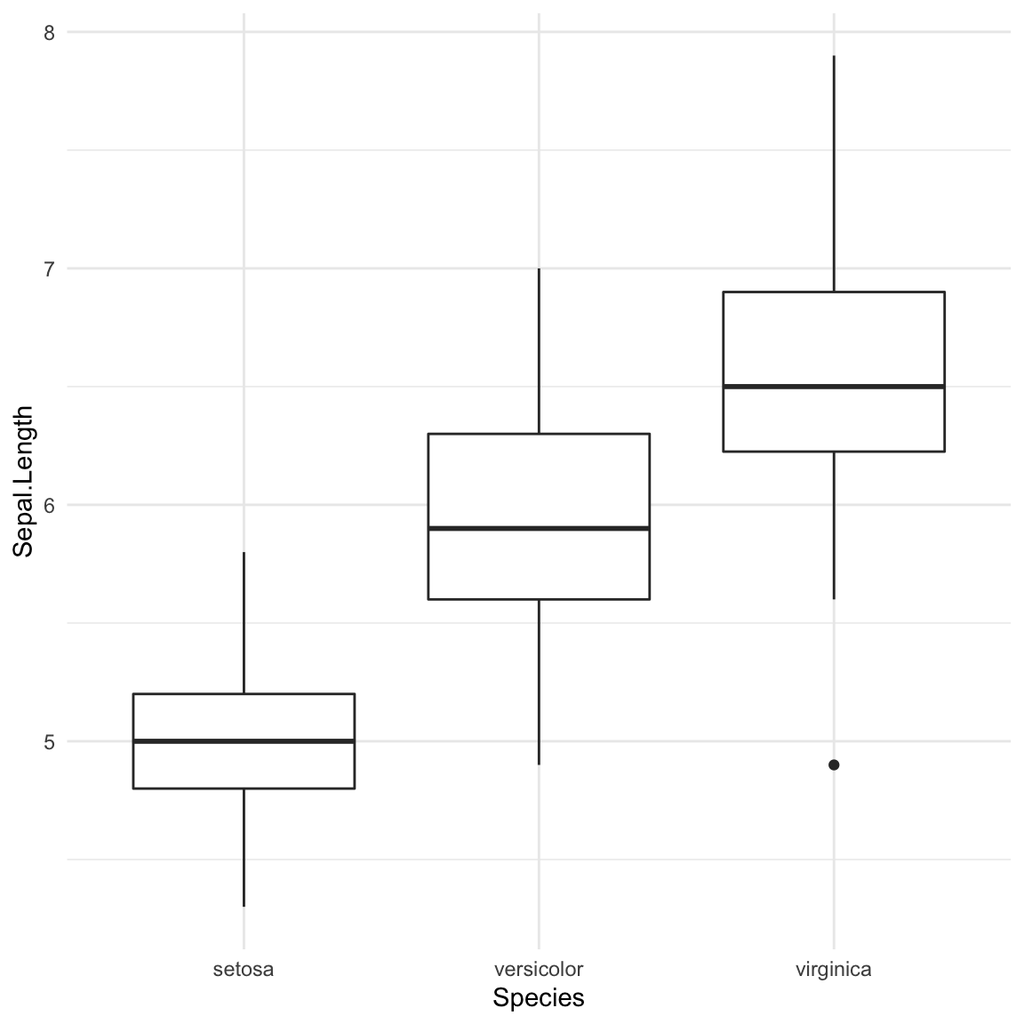

# Adding colour to a plot

[video not shown]

**Video summary**

- The points of a scatterplot can be coloured based on a third column of data
- We can colour points using categorical *or* continuous data
- The `aes(..., colour=column_name)` option selects the column to use (change `column_name` to the name of *your* column)

**Code examples**

```r
# colour each point; different colour for each Species
iris %>%
  ggplot(aes(Sepal.Length, Sepal.Width, color = Species)) +
  geom_point()
```

**Video Transcript**

As we saw before, scatterplots show the relationship between two variables.

Using the `mpg` data, we could plot the size of car engines (`displ`, short for displacement) against their fuel efficiency on the highway in miles per gallon (`hwy`):

```r
mpg %>%
  ggplot(aes(displ, hwy)) +
  geom_point()
```

*NOTE: This first plot is not shown here to save space, but is shown in the video.*

Colour can be added to distinguish the points — for example, what kind of car each point represents.

So far, you’ve used the `aes()` function to define which variable is plotted on the x and y axes. The `aes()` function is short for ‘aesthetics’ (what we can see) and *connects columns in our data to visual aspects of a plot*, like the x and y axes.

The `colour=...` option adds to this, and says which column is used to colour the points. In the `mpg` data, the `drv` column records if a car is front (`f`), rear (`r`) or four (`4`) wheel drive.

We can write `color=drv` to tell R to colour each point, depending on which wheels are driven:

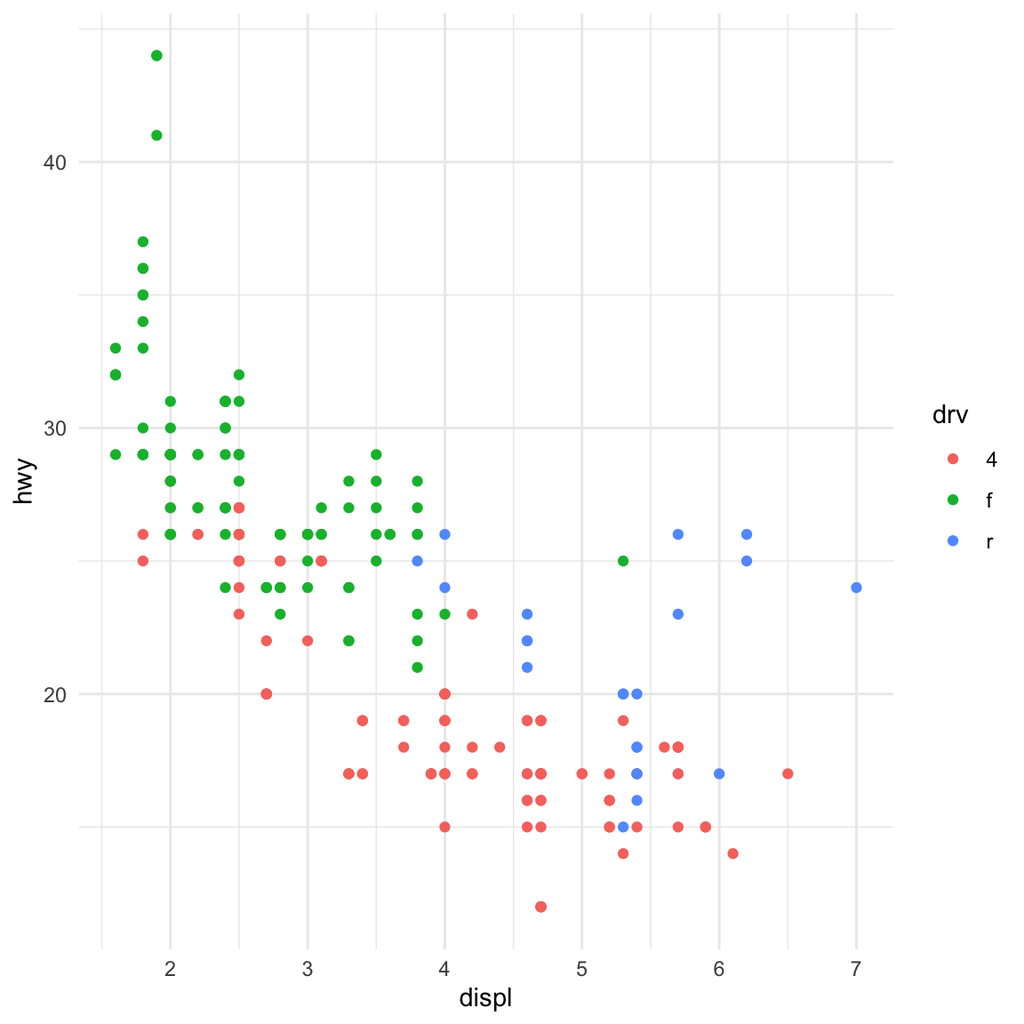

```r
# colour each point; different colour for each type of transmission
# front, rear and four wheel drive
mpg %>%
  ggplot(aes(displ, hwy, color=drv)) +
  geom_point()
```

This is an example of using a *categorical* variable to colour our points.

Notice that `ggplot()` automatically adds a key to the plot, mapping the colour of the points to the categories in `drv`.

**Exercise 2**

1. Use the `development` data from the `psydata` package (run `library(psydata)` first if you haven’t already)
2. Create a scatterplot with `life_expectancy` on the x-axis (along the bottom) and `gdp_per_capita` on the y-axis
3. Add colour to this scatterplot: make each `continent` a different colour
4. Run the chunk of code

Your plot should look like this:

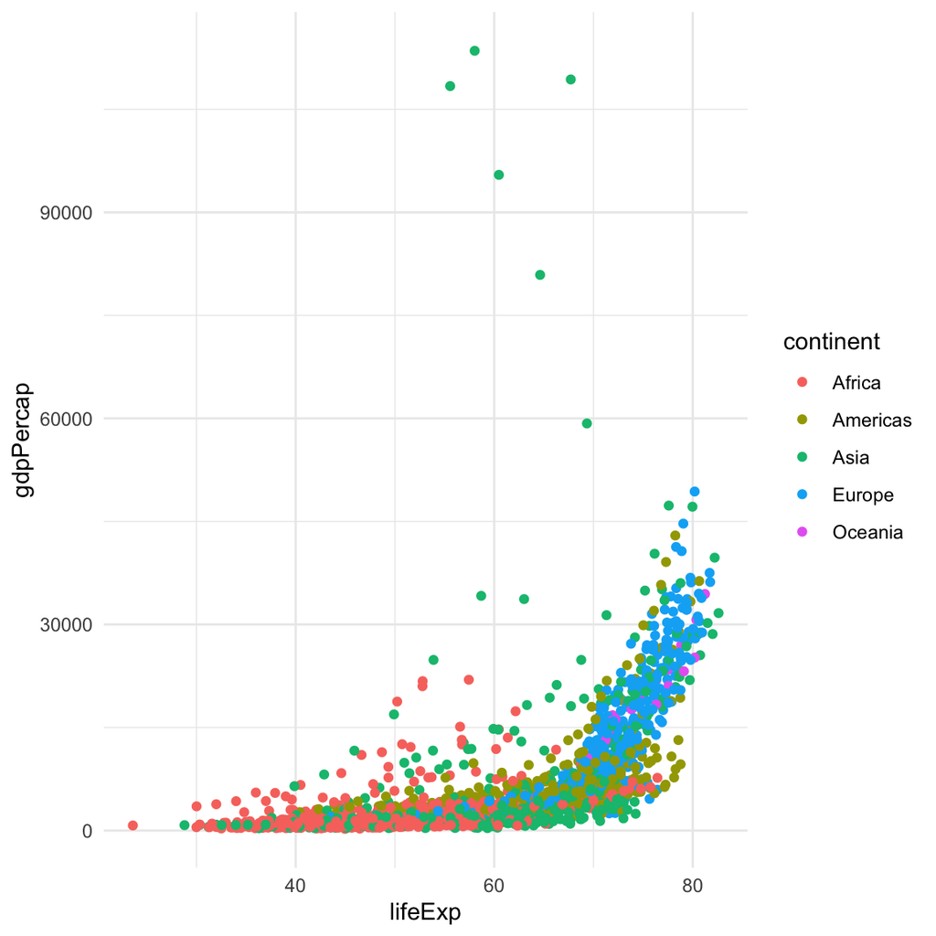

# Using different types of data and visual scales

[video not shown]

**Video summary**

- Continuous, categorical and text data are all common in psychology
- Internally, R stores columns of data using different *data types*.
- R uses data types as a clue to set *defaults* (e.g. for graphs)
- Sometimes we need to convert between types
- For example, sometimes categorical data is (wrongly) stored as a numeric column

**Code examples**

```r
# always load the libraries we need first
library(tidyverse)
library(psydata)

# see a list of columns in the dataset, and their types
iris %>% glimpse

# make a scatter plot with two continous axes
# both wt and mpg are numeric variables
# so this works well
fuel %>%
  ggplot(aes(weight, mpg)) +
    geom_point()

# try and make a boxplot with `am` as the x axis
# but because `cyl` is stored as a numeric variable
# (not categorical) the scale of the x axis is wrong
fuel %>%
  ggplot(aes(cyl, mpg)) +
  geom_boxplot()

# re-draw the plot, but converting `cyl` to a factor/categorical
# variable first. Now the x axis looks correct
fuel %>%
  ggplot(aes(factor(cyl), mpg)) +
  geom_boxplot()
```

**Video Transcript**

The video introduces:

- the different types of data we may have (e.g. continuous, categorical, text)
- the way R stores these data and
- the way that `ggplot()` presents them

These might seem like small details — but having some understanding of what is happening will help later on: you will be able to control how your data are presented in tables and plots. It will also help you make sure your data are in the right format for other statistical tests.

### Columns vs variables

This is really important. Make sure you are clear on the different meanings of the word ‘variable’

The word *variable* gets used in at least 4 different ways in quantitative research, and this confuses a lot of people. We can’t avoid all ambiguity because these different usages are common in the field, but it helps to know about them in advance:

- *variables in a theoretical model*. That is, things we think exist, and which *cause* other things to happen. An example would be “empathy”, or “working memory”.
- *variables in a study design*. For example an experimental group allocation, or an attribute of participants like age or gender.
- *variables in a dataset*. Here we mean a column of numbers in a dataset (e.g. a spreadsheet), where the column has a name. This usage overlaps with the previous two, but doesn’t have to. For example, we might have a column of numbers recording participants’ scores on an empathy questionnaire. But we might also have a column containing reaction times for multiple trials; analysed a certain way these reaction times might tell us something about working memory, but the column of reaction times isn’t the same thing as the variable in our theoretical model.
- *variables in R and computer programs*: This type of variable is a *general purpose container* which can store anything. Variables in R *can* contain columns of numbers, but they can also contain whole datasets, or graphs, or the results of statistical tests. **A variable in R often isn’t the same thing as an experimental variable or a column in a dataset**.

**In this guide use *variable* to mean either an experimental/theoretical variable or an R container.** **When we mean a column of data in a dataset we will use the word *column* instead.**

### Types of variable

If we are thinking about variables in a study design the main *types* to consider are:

- *categorical* or *nominal* variables (sometimes also called *factors*): e.g. gender, education status
- *binary* variables (a special category that is either `TRUE` or `FALSE`): e.g. smoker/non-smoker
- *ordinal* variables (categorical responses where the order is important): e.g. a 1-7 response on a Likert-style question
- *interval* or *continuous* variables: e.g. weight in kg, time in milliseconds
- *count* variables (a frequency, measured in whole numbers): e.g. number of social contacts per week
- *text* variables: e.g. free text responses to open-ended questionnaire items

### Types of column

Datasets have multiple columns, each with a unique name.

In R, every column has a *data type*. These data types are normally determined by the type of variable. But there is some overlap, and different data types could be used to store the same variable. We sometimes need to convert between data types.

There are four data types you need to know about in R:

- *Factors*, which are used for categorical data (and sometimes ordinal data too)
- *Text*, also called *character* or *string* data.
- *Numeric* columns can called be either *integer* or *double*. Double is computer speak for ‘double-precision number’, which just means decimals and really big numbers are allowed
- *Logical*, which can be used to store values that can only be either True or False.

The important thing to know is that, although different types of variable are usually stored in the same type of column in R, *this isn’t always the case*. Sometimes data can be stored as the wrong type—e.g. categorical data can end up stored as continuous— and in these cases we need to convert from one format to another.

You can see which data type is used to store a variable when using the `glimpse()` command introduced in Session 1 (see here).

```r
iris %>% glimpse()
Rows: 150
Columns: 5
$ Sepal.Length <dbl> 5.1, 4.9, 4.7, 4.6, 5.0, 5.4, 4.6, 5.0, 4.4, 4.9, 5.4, 4.8, 4.8, 4.3, 5.8, 5.7, 5.4, 5.1, 5.7, 5.1, 5.4, …
$ Sepal.Width  <dbl> 3.5, 3.0, 3.2, 3.1, 3.6, 3.9, 3.4, 3.4, 2.9, 3.1, 3.7, 3.4, 3.0, 3.0, 4.0, 4.4, 3.9, 3.5, 3.8, 3.8, 3.4, …
$ Petal.Length <dbl> 1.4, 1.4, 1.3, 1.5, 1.4, 1.7, 1.4, 1.5, 1.4, 1.5, 1.5, 1.6, 1.4, 1.1, 1.2, 1.5, 1.3, 1.4, 1.7, 1.5, 1.7, …
$ Petal.Width  <dbl> 0.2, 0.2, 0.2, 0.2, 0.2, 0.4, 0.3, 0.2, 0.2, 0.1, 0.2, 0.2, 0.1, 0.1, 0.2, 0.4, 0.4, 0.3, 0.3, 0.3, 0.2, …
$ Species      <fct> setosa, setosa, setosa, setosa, setosa, setosa, setosa, setosa, setosa, setosa, setosa, setosa, setosa, s…
```

In the output you can see the variable names listed on the left, followed by text in angle brackets, e.g.: `<dbl>` which is the abbreviated name of data type.

In this built-in dataset, most of the data is numeric (`dbl`), but the `Species` variable is categorical, and stored as a factor (`fct`).

It’s possible to convert columns from one type to another, to suit our needs. We’ll see more of this later.

| Data/column type | Useful for | Abbreviations used/subtypes | Often need to convert from |
| --- | --- | --- | --- |
| Factor | categorical, ordinal | `fct`, `ord` | text |
| Text | text, categorical | `chr` | categorical |
| Numeric | continuous, ordinal | `int`, `dbl` | categorical; text |
| Logical | binary (boolean) | `lgl` | numeric |

### Column types determine the scales on graphs

If we look at the `fuel` data we can see that most of the columns are stored as numeric data (`dbl`):

```r
fuel %>% glimpse()
Rows: 32
Columns: 7
$ mpg         <dbl> 21.0, 21.0, 22.8, 21.4, 18.7, 18.1, 14.3, 24.4, 22.8, 19.2, 17.8, 16.4, 17.3, 15.2, 10.4, 10.4, 14.7, 32.4…
$ cyl         <dbl> 6, 6, 4, 6, 8, 6, 8, 4, 4, 6, 6, 8, 8, 8, 8, 8, 8, 4, 4, 4, 4, 8, 8, 8, 8, 4, 4, 4, 8, 6, 8, 4
$ engine_size <dbl> 2620, 2620, 1770, 4230, 5900, 3690, 5900, 2400, 2310, 2750, 2750, 4520, 4520, 4520, 7730, 7540, 7210, 1290…
$ power       <dbl> 110, 110, 93, 110, 175, 105, 245, 62, 95, 123, 123, 180, 180, 180, 205, 215, 230, 66, 52, 65, 97, 150, 150…
$ weight      <dbl> 1188, 1304, 1052, 1458, 1560, 1569, 1619, 1447, 1429, 1560, 1560, 1846, 1692, 1715, 2381, 2460, 2424, 998,…
$ gear        <dbl> 4, 4, 4, 3, 3, 3, 3, 4, 4, 4, 4, 3, 3, 3, 3, 3, 3, 4, 4, 4, 3, 3, 3, 3, 3, 4, 5, 5, 5, 5, 5, 4
$ automatic   <lgl> TRUE, TRUE, TRUE, FALSE, FALSE, FALSE, FALSE, FALSE, FALSE, FALSE, FALSE, FALSE, FALSE, FALSE, FALSE, FALS…
```

This is fine if we want to make a scatter plot. In the example below we have ‘miles per gallon’ vs the weight of cars in the `fuel` dataset (in `psydata`):

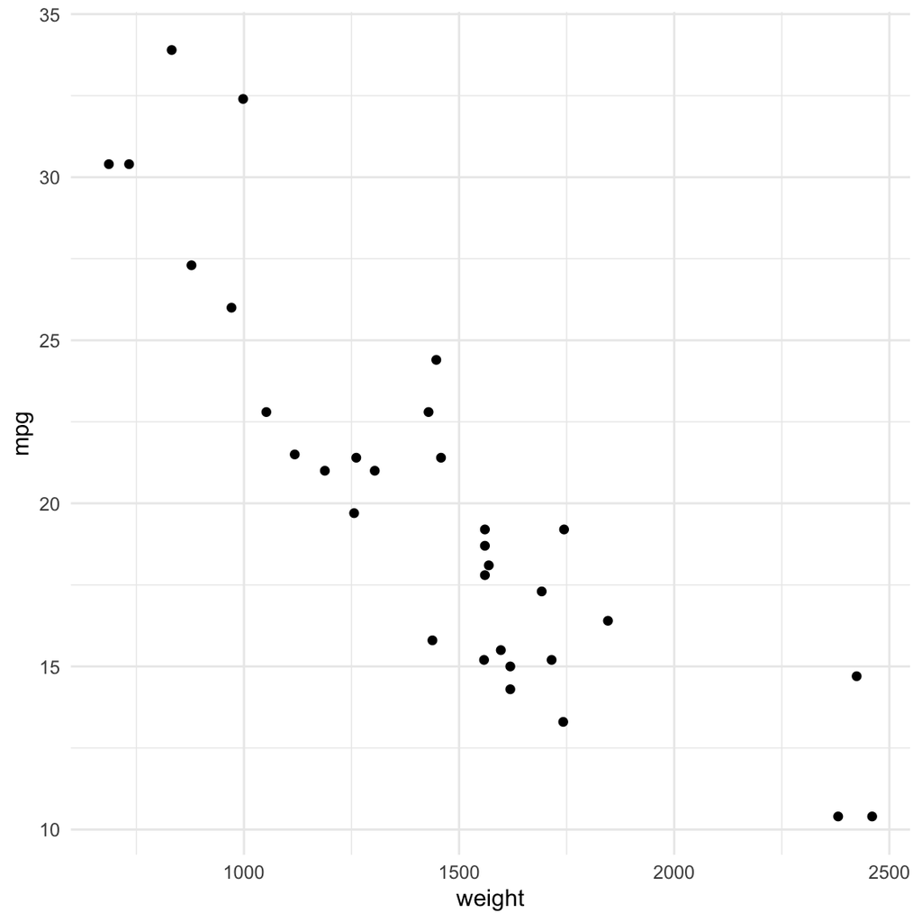

```r
fuel %>%
  ggplot(aes(weight, mpg)) +
    geom_point()
```

In this scatterplot both the x and y axes are *continuous*. That is, they are numeric variables, using real numbers.

However, if we want to make a boxplot of the `mpg` column using `cyl` (number of cylinders) as the `x` axis then we have a problem:

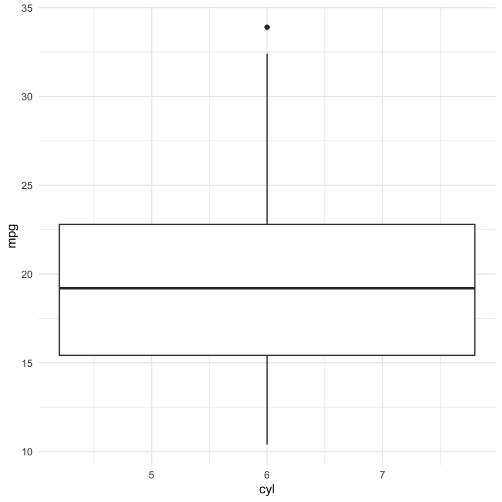

```r
fuel %>%
  ggplot(aes(cyl, mpg)) +
  geom_boxplot()
Warning: Continuous x aesthetic -- did you forget aes(group=...)?
```

The warning message says `Continuous x aesthetic -- did you forget aes(group=...)?`. This is a clue as to what has gone wrong.

We might have expected to see;

- miles per gallon on the $y$ axis
- three separate boxes, one each for 4, 6 and 8 cylinders

This doesn’t work as expected though.

We want to use `cyl` as a categorical variable, so we should convert it to a `factor`. Then our plot will work properly.

We can use the command `factor(cyl)` to tell R that the $x$-axis is a factor:

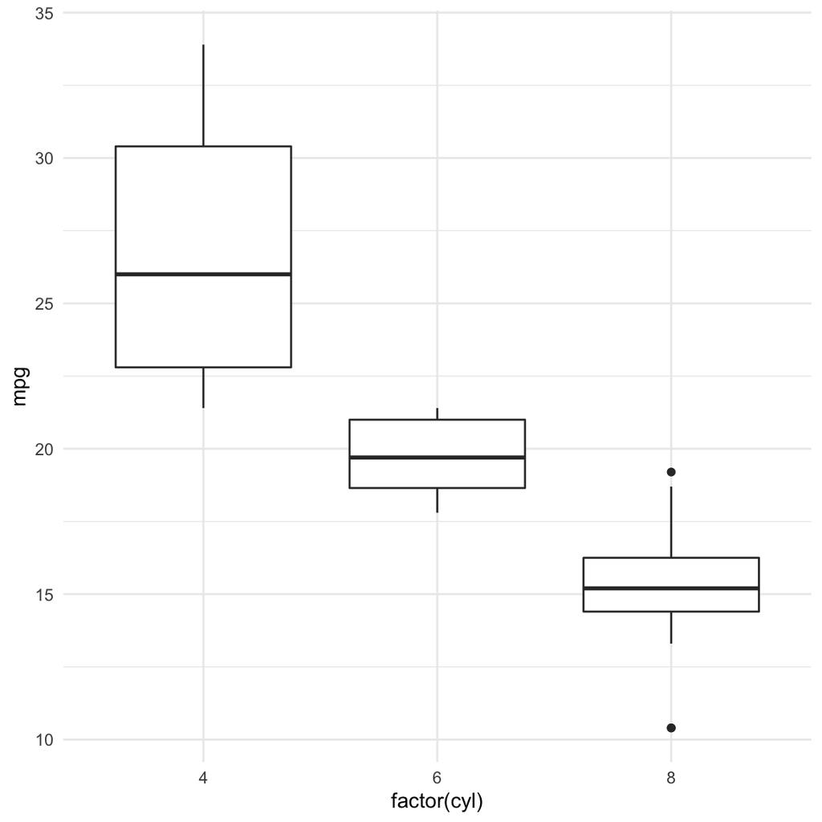

```r
fuel %>%
  ggplot(aes(factor(cyl), mpg)) +
  geom_boxplot()
```

This gives us the boxplot we were expecting. The only change was to replace `cyl` with `factor(cyl)`. This tells R to convert the variable `cyl` to a factor, and `ggplot()` can then set the scale of the x axis correctly.

**Exercise 3**

Work with a friend: Describe the 4 ways in which quantitative researchers might use the word ‘variable’?

(If you need to look these up from the video or text above then try testing yourself again after completing other exercises).

**Exercise 4**

Use `glimpse()` to check the data types of the `mpg` and the `diamonds` datasets.

- The data type of the 4th variable in the `mpg` data is
- The data type 5th variable in the `diamonds` data is

**Exercise 5**

Use the `fuel` dataset to make a boxplot showing miles per gallon on the y-axis, and number of gears (`gear`) on the x-axis. Your plot should look like this:

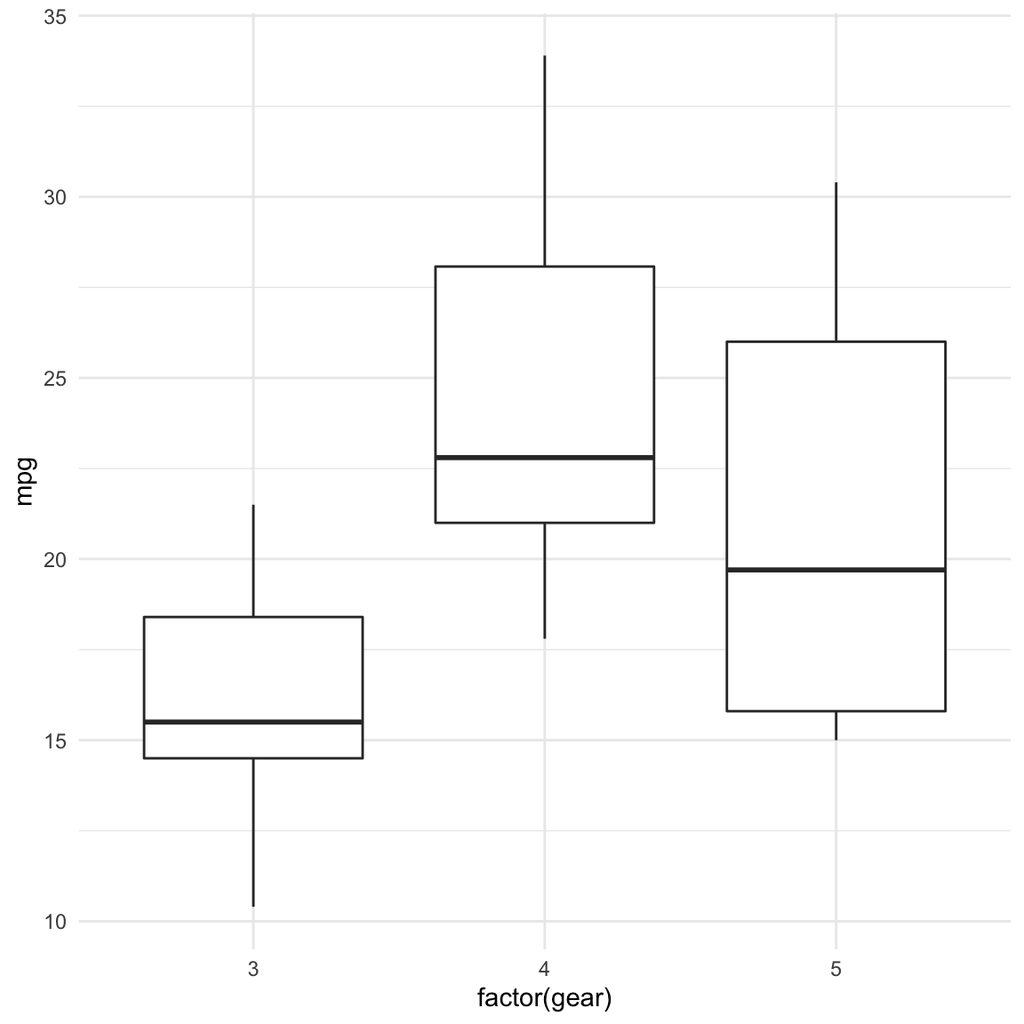

Remember that you will need to *change* the type of the `gear` variable for this to work.

# Using `group_by()` to make a summary table and compare groups

[video not shown]

**Video summary**

- Datasets often contain categorical variables
- We often want to compare statistics (like averages) *between* categories
- The `group_by()` function is a quick way to combine filtering and summarising
- `group_by()` creates a *grouped* `data.frame`
- Adding `group_by()` to a pipeline runs the subsequent steps *once for each group*.
- The result is always a new `data.frame`

**Code examples**

```r
# check the columns in the funimagery dataset
# results of an RCT of functional imagery training for weight loss
# conducted at the University of Plymouth
funimagery %>% glimpse

# boxplot to compare the intervention groups
funimagery %>%
  ggplot(aes(intervention, weight_lost_end_trt)) +
  geom_boxplot()


# calculate mean weight loss in each group in a laborious way
funimagery %>%
  filter(intervention=="MI") %>%
  summarise(mean(weight_lost_end_trt))

funimagery %>%
  filter(intervention=="FIT") %>%
  summarise(mean(weight_lost_end_trt))


# use group_by to split the data and summarise each group
funimagery %>%
  group_by(intervention) %>%
  summarise(mean(weight_lost_end_trt))

# store the result (also a data.frame) in a new variable
average_weight_loss <- funimagery %>%
                          group_by(intervention) %>%
                          summarise(mean(weight_lost_end_trt))


# example of grouping by two columns at once
funimagery %>%
  group_by(gender, intervention) %>%
  summarise(mean(weight_lost_end_trt))



# calculate the mean and SD in one go
funimagery %>%
  group_by(intervention) %>%
  summarise(
    mean(weight_lost_end_trt),
    sd(weight_lost_end_trt)
  )


# how to give your new summary columns a name
# (this is good practice)
funimagery %>%
  group_by(intervention) %>%
  summarise(
    mean_weight_lost_end_trt = mean(weight_lost_end_trt),
    sd_weight_lost_end_trt = sd(weight_lost_end_trt)
  )
```

**Video Transcript**

In this video we’ll use the `funimagery` dataset (in the `psydata`) package. This contains data from a randomised controlled trial run in Plymouth (Solbrig et al., 2019).

The study compared two treatments for weight loss: Functional Imagery Training (FIT) and Motivational Interviewing (MI).

We can see the columns in the dataset using `glimpse()`:

```r
funimagery %>% glimpse
Rows: 112
Columns: 8
$ gender              <chr> "f", "f", "f", "f", "f", "f", "f", "m", "f", "f", "m", "f", "f", "f", "m", "m", "f", "f", "f", "m"…
$ age                 <int> 44, 32, 33, 21, 27, 56, 50, 57, 34, 25, 70, 56, 55, 43, 37, 45, 60, 51, 21, 43, 21, 19, 65, 40, 45…
$ kg1                 <dbl> 107.8, 107.0, 99.5, 80.0, 81.0, 59.0, 95.0, 90.0, 87.0, 121.2, 84.0, 100.0, 87.4, 100.4, 89.5, 84.…
$ kg2                 <dbl> 106.7, 105.4, 101.0, 79.0, 80.0, 57.0, 92.0, 87.0, 87.0, 123.0, 81.9, 97.2, 85.0, 99.1, 91.0, 85.6…
$ kg3                 <dbl> 106.0, 105.9, 98.8, 78.0, 80.0, 60.0, 92.0, 87.0, 86.4, 119.7, 84.0, 98.0, 84.9, 100.0, 91.5, 86.2…
$ person              <int> 4, 5, 6, 7, 8, 9, 10, 11, 12, 13, 14, 15, 16, 17, 18, 19, 20, 21, 22, 23, 24, 25, 26, 27, 28, 29, …
$ intervention        <fct> MI, MI, MI, MI, MI, MI, MI, MI, MI, MI, MI, MI, MI, MI, MI, MI, MI, MI, MI, MI, MI, MI, MI, MI, MI…
$ weight_lost_end_trt <dbl> -1.1, -1.6, 1.5, -1.0, -1.0, -2.0, -3.0, -3.0, 0.0, 1.8, -2.1, -2.8, -2.4, -1.3, 1.5, 1.4, -4.3, -…
```

Weight was measured three times, and these measurements are in the columns called `kg1`, `kg2` and `kg3`.

- The first (`kg1`) was taken at *baseline*, when participants joined the study
- The second (`kg2`) was taken at the end of treatment, 6 months after baseline
- The final measurement (`kg3`) was made 12 months after baseline

The `weight_lost_end_trt` column is the *difference* between `kg1` and `kg2` – i.e. how much weight the participant lost after their treatment.

We have already seen a plot like this which can compare scores between categories:

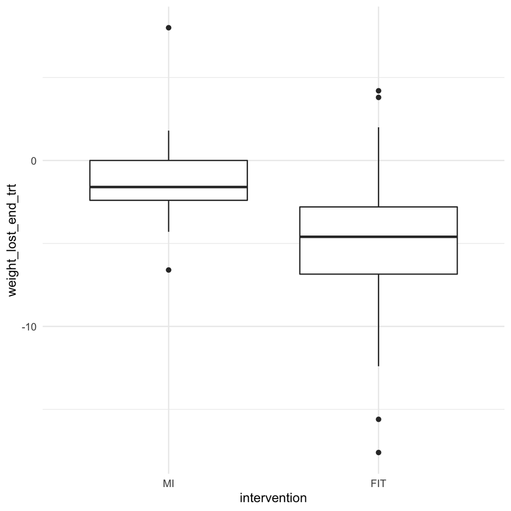

```r
funimagery %>%
  ggplot(aes(intervention, weight_lost_end_trt)) +
  geom_boxplot()
```

This graph is helpful, and makes the differences really clear. But what if we want the actual numbers in a table, or to report in the text of our paper?

### Using `filter()` and `summarise()`

One option would be to filter our data first and then summarise each subset in turn:

```r
funimagery %>%
  filter(intervention=="MI") %>%
  summarise(mean(weight_lost_end_trt))
  mean(weight_lost_end_trt)
1                 -1.245283
```

The output (underneath the code) shows us the mean for the MI group. We then have to repeat that step for the FIT group:

```r
funimagery %>%
  filter(intervention=="FIT") %>%
  summarise(mean(weight_lost_end_trt))
  mean(weight_lost_end_trt)
1                 -5.091525
```

That would be repetitive though, and would get annoying if there were lots of categories. Imagine doing something similar for each continent in the `development` data, for example.

### Using `group_by()`

Instead of using `filter()`, we can use `group_by()` to split our dataset into multiple groups, summarising each one separately:

```r
funimagery %>%
  group_by(intervention) %>%
  summarise(mean(weight_lost_end_trt))
# A tibble: 2 x 2
  intervention `mean(weight_lost_end_trt)`
  <fct>                              <dbl>
1 MI                                 -1.25
2 FIT                                -5.09
```

Using `group_by()` before `summarise()` splits up the data depending on which `intervention` the participant was randomised to. The `summarise()` function calculates the mean for each group separately.

The result is a new `data.frame` with two columns: The name of the `intervention`, and the average weight lost. We could save this in a new variable for use later, if we liked:

```r
average_weight_losses <- funimagery %>%
                          group_by(intervention) %>%
                          summarise(mean(weight_lost_end_trt))
```

If you run this code, you can now see the new variable in the **Environment**, so it’s stored for later.

### Nested groups

Sometimes we might want to group by more than one variable at once.

Imagine we wanted to see if men and women responded differently to the two treatments?

With `group_by()` this is really easy: just add the name of another column to group on (`gender`), separated with a comma:

```r
funimagery %>%
  group_by(gender, intervention) %>%
  summarise(mean(weight_lost_end_trt))
# A tibble: 4 x 3
# Groups:   gender [2]
  gender intervention `mean(weight_lost_end_trt)`
  <chr>  <fct>                              <dbl>
1 f      MI                                 -1.2
2 f      FIT                                -5.56
3 m      MI                                 -1.37
4 m      FIT                                -3.84
```

It looks like women lost a bit more weight on average, but FIT was better than MI for both men and women.

### Multiple statistics

With `summarise()` we can calculate multiple statistics at once for each of the groups:

```r
funimagery %>%
  group_by(intervention) %>%
  summarise(mean(weight_lost_end_trt), sd(weight_lost_end_trt))
# A tibble: 2 x 3
  intervention `mean(weight_lost_end_trt)` `sd(weight_lost_end_trt)`
  <fct>                              <dbl>                     <dbl>
1 MI                                 -1.25                      2.09
2 FIT                                -5.09                      4.18
```

### Give your new variables a name

R gives the new columns a name based on the function we use to `summarise()` them.

For example, if we use `mean()` on the `weight_lost_end_trt` variable then the new column is called `mean(weight_lost_end_trt)`.

- rerun code above and highlight where the name of the variable comes from

Unfortunately, these new variable names contain parentheses and (sometimes) spaces which makes them harder to work with. It’s much better to give the new column a specific name like this:

```r
funimagery %>%
  group_by(intervention) %>%
  summarise(mean_weight_lost_end_trt = mean(weight_lost_end_trt), sd_weight_lost_end_trt = sd(weight_lost_end_trt))
# A tibble: 2 x 3
  intervention mean_weight_lost_end_trt sd_weight_lost_end_trt
  <fct>                           <dbl>                  <dbl>
1 MI                              -1.25                   2.09
2 FIT                             -5.09                   4.18
```

As a reminder, the names you use shouldn’t include spaces or other ‘special’ characters.

**Exercise 6**

Replace the `?` in the code below to to calculate the `median` weight lost for men and women undergoing FIT and MI in the `funimagery` dataset:

```r
? %>%
  group_by(?, ?) %>%
  summarise( ?(weight_lost_end_trt) )
```

These are the correct numbers to check your work against:

| Gender | Intervention | Median weight loss |
| --- | --- | --- |
| Female | MI | -1.3 |
| Female | FIT | -4.6 |
| Male | MI | -2.1 |
| Male | FIT | -4.3 |

**Exercise 7**

Use `group_by()` and `summarise()` with the built-in `iris` dataset to calculate the mean `Sepal.Length` for each `Species` of flower.

These are the correct numbers to check your work against:

| Species | Mean sepal length |
| --- | --- |
| setosa | 5.0 |
| versicolor | 5.9 |
| virginica | 6.6 |

**Exercise 8**

The built-in dataset `chickwts` contains weights of chicks (in grams) fed on different diets. Use `group_by()` and `summarise()` to calculate the mean and standard deviation chick weights for each type of feed.

The mean weight of chicks fed on linseed was g.

The standard deviation of chicks fed on sunflower was g.

# Check your knowledge

Write an answer to each of these questions in the `Check your knowledge` section of your workbook. The answers will be revealed in Session 4.

1. Which functions are needed to make a boxplot?
2. What is the difference between a `dbl` and a `fct` or `ord`?
3. Which datatypes are used for continuous variables?
4. Give an example of why the difference between `dbl` and `fct` matters when making a plot (include code examples for this if you can)
5. How can you convert a variable from a `dbl` to a `fct`?
6. How could you calculate the mean for one level of a factor?
7. How would you calculate the mean for all levels of a factor (e.g. for continent in the `development` dataset)?
8. How would you calculate means and standard deviations for all combinations of levels in two factors?

# Extension exercises

*Please remember that these extension exercises are *not* required to pass the course.* We include them because some students work through these materials much more quickly than others — perhaps because they have more previous experience with programming — and we aim to give all students the opportunity to stretch their skills.

If you do find you have extra time, however, these exercises are intended to provide additional practice in the technqiues taught here, and to be useful preparation for using R independently in a stage 4 or MSc research project.

**Extension exercise 1**

Make a scatterplot of the `diamonds` data. Show `carat` on the x-axis, `price` on the y-axis, and the `clarity` of the diamonds in colour. Try to produce your plot *before* comparing it against the answer using the button below.

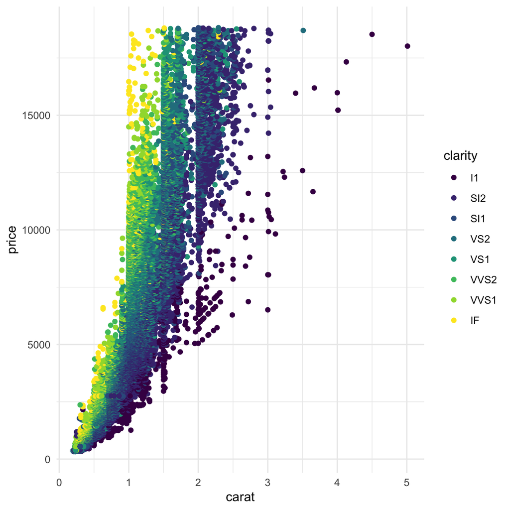

Interpret your plot: Which category of diamond `clarity` has the steepest rise in price as size (carat) increases?

**Extension exercise 2**

Make a scatterplot of the `fuel` dataset. Show `mpg` on the y-axis, engine size on the x-axis, and use type of transmission (auto/manual) to colour the points. Try to produce your plot before comparing it against the answer using the button below.

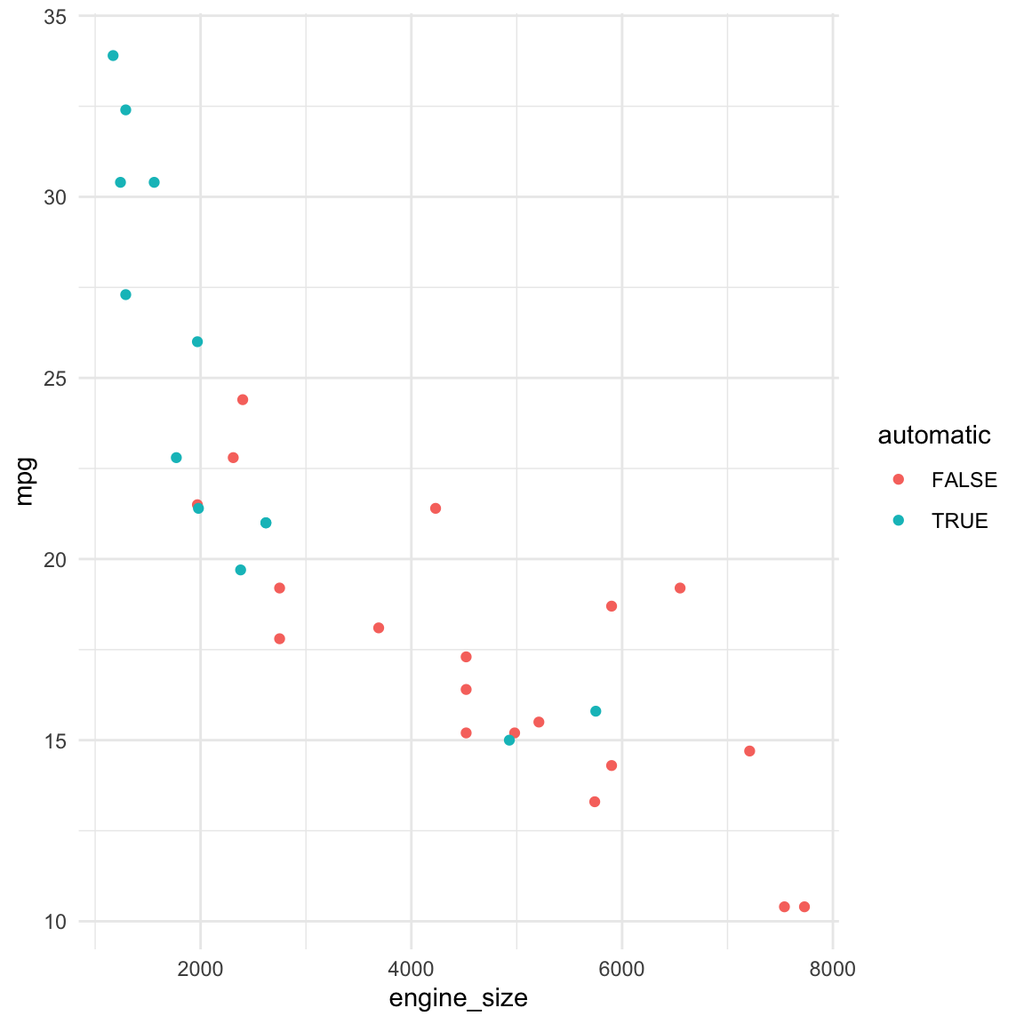

Interpret your plot: Which type of car (auto or manal) sees the strongest relationship between engine size and fuel economy?

**Extension exercise 3**

Using the `development` dataset, make a boxplot showing life expectancy by continent for years greater than 1999. (Hint: use `filter()`, `ggplot()` and `geom_boxplot()`.)

The plot should look like this:

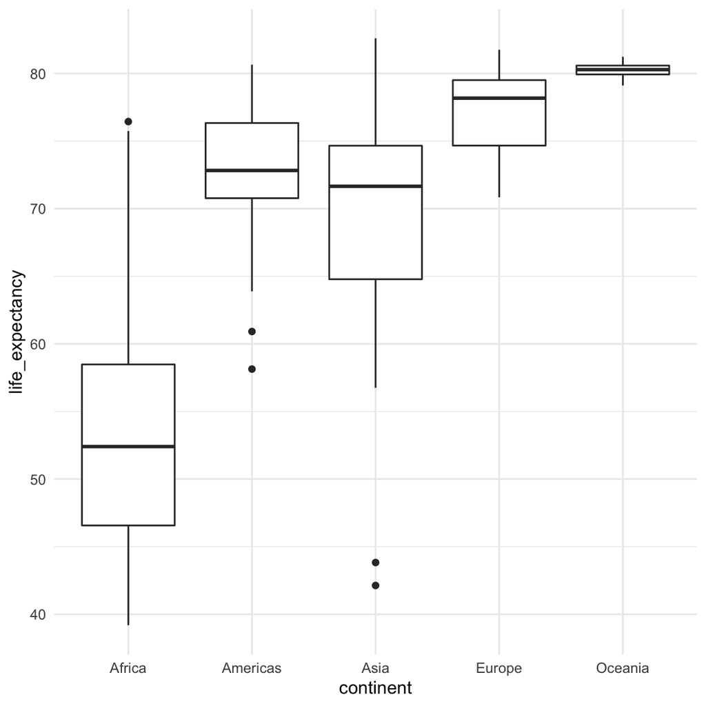

**Extension exercise 4**

Try to recreate the plot below using the `mtcars` built-in dataset. Remember to use `factor()` for columns which require conversion to `fct`.

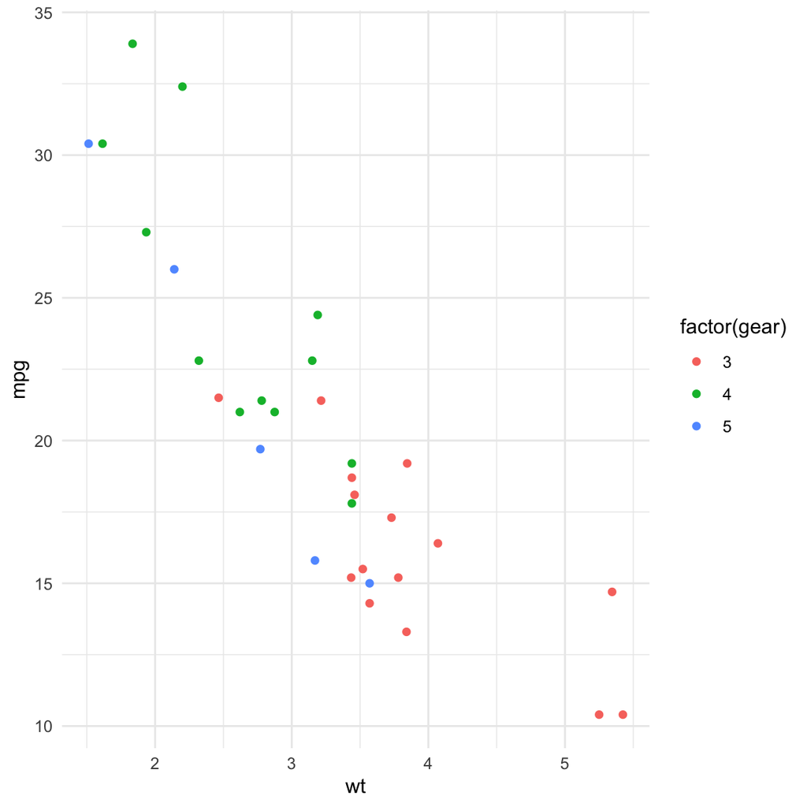

**Extension exercise 5**

Try to recreate the table below using the `painmusic` dataset from `psydata`.

```
# A tibble: 4 x 4
# Groups:   liked [2]
  liked    familiar   mean_pain_no_music sd_pain_no_music
  <fct>    <fct>                   <dbl>            <dbl>
1 Disliked Familiar                 5.5              2.06
2 Disliked Unfamiliar               5.86             2.09
3 Liked    Familiar                 4.75             2.07
4 Liked    Unfamiliar               5.21             1.93
```

# References

Solbrig, L., Whalley, B., Kavanagh, D. J., May, J., Parkin, T., Jones, R., & Andrade, J. (2019). Functional imagery training versus motivational interviewing for weight loss: A randomised controlled trial of brief individual interventions for overweight and obesity. *International Journal of Obesity*, *43*(4), 883–894.